# Peer Assessment 1

# Introduction

It is now possible to collect a large amount of data about personal movement using activity monitoring devices such as a Fitbit, Nike Fuelband, or Jawbone Up. These type of devices are part of the “quantified self” movement - a group of enthusiasts who take measurements about themselves regularly to improve their health, to find patterns in their behavior, or because they are tech geeks. But these data remain under-utilized both because the raw data are hard to obtain and there is a lack of statistical methods and software for processing and interpreting the data.

This assignment makes use of data from a personal activity monitoring device. This device collects data at 5 minute intervals through out the day. The data consists of two months of data from an anonymous individual collected during the months of October and November, 2012 and include the number of steps taken in 5 minute intervals each day.

# Data

The data for this assignment can be downloaded from the course web site: - Dataset: Activity monitoring data [52K]

- he variables included in this dataset are:

.steps: Number of steps taking in a 5-minute interval (missing values are coded as NA)

- date: The date on which the measurement was taken in YYYY-MM-DD format
- interval: Identifier for the 5-minute interval in which measurement was taken

The dataset is stored in a comma-separated-value (CSV) file and there are a total of 17,568 observations in this dataset.

# Assignment

This assignment will be described in multiple parts. You will need to write a report that answers the questions detailed below. Ultimately, you will need to complete the entire assignment in a single R markdown document that can be processed by knitr and be transformed into an HTML file.

Throughout your report make sure you always include the code that you used to generate the output you present. When writing code chunks in the R markdown document, always use echo = TRUE so that someone else will be able to read the code. This assignment will be evaluated via peer assessment so it is essential that your peer evaluators be able to review the code for your analysis.

For the plotting aspects of this assignment, feel free to use any plotting system in R (i.e., base, lattice, ggplot2)

Fork/clone the GitHub repository created for this assignment. You will submit this assignment by pushing your completed files into your forked repository on GitHub. The assignment submission will consist of the URL to your GitHub repository and the SHA-1 commit ID for your repository state.

NOTE: The GitHub repository also contains the dataset for the assignment so you do not have to download the data separately.

## Loading and preprocessing the data

**1.Load the data (i.e. read.csv())**

```r
setwd("c:/Coursera/RR")
actdf <- read.csv("activity.csv", header=TRUE)
```

Let’s check the data dimension and summary.

```r
dim(actdf)
```

```
## [1] 17568     3
```

```r
summary(actdf)
```

```
##      steps                date          interval
##  Min.   :  0.00   2012-10-01:  288   Min.   :   0.0
##  1st Qu.:  0.00   2012-10-02:  288   1st Qu.: 588.8
##  Median :  0.00   2012-10-03:  288   Median :1177.5
##  Mean   : 37.38   2012-10-04:  288   Mean   :1177.5
##  3rd Qu.: 12.00   2012-10-05:  288   3rd Qu.:1766.2
##  Max.   :806.00   2012-10-06:  288   Max.   :2355.0
##  NA's   :2304     (Other)   :15840
```

```r
str(actdf)
```

```
## 'data.frame':    17568 obs. of  3 variables:
##  $ steps   : int  NA NA NA NA NA NA NA NA NA NA ...
##  $ date    : Factor w/ 61 levels "2012-10-01","2012-10-02",..: 1 1 1 1 1 1 1 1 1 1 ...
##  $ interval: int  0 5 10 15 20 25 30 35 40 45 ...
```

The data has 17568 rows and 3 columns. Steps and interval are integers and data is a factor. There are missing values in the field of steps.

**2.Process/transform the data (if necessary) into a format suitable for your analysis**

Let’s add a column dateval as a date type. Add columns of day to reflect weekday names and IsWeekday to reflect weekday/weekend.

```r
actdf$dateval<-as.Date(substring(actdf$date,1,11))
actdf$day <- weekdays(actdf$dateval) #Weekday
weekdays1ist <- c('Monday', 'Tuesday', 'Wednesday', 'Thursday', 'Friday')
actdf$IsWeekday <- actdf$day %in% weekdays1ist
actdf$IsWeekday<-ifelse(actdf$IsWeekday == "TRUE", "weekday", "weekend")
```

Let’s check the ‘NA’ value for the dataframe.

```r
na_count <-sapply(actdf, function(y) sum(length(which(is.na(y)))))
na_count
```

```
##     steps      date  interval   dateval       day IsWeekday
##      2304         0         0         0         0         0
```

There are 2304 ‘NA’ values in the column steps. Let’s split the dataframe into:  
* dfgood without ‘NA’ in steps  
* dfbad with ‘NA’ in steps.

```r
dfgood<-subset(actdf, !(is.na(steps)))
dfbad<-subset(actdf, is.na(steps))
```

## What is mean total number of steps taken per day?

**1.Calculate the total number of steps taken per day**

```r
TStepsPerDay<-aggregate(dfgood$steps, list(dfgood$date), sum) #sum total steps per day
colnames(TStepsPerDay) <- c("date", "TotalSteps") #change column names
head(TStepsPerDay)
```

```
##         date TotalSteps
## 1 2012-10-02        126
## 2 2012-10-03      11352
## 3 2012-10-04      12116
## 4 2012-10-05      13294
## 5 2012-10-06      15420
## 6 2012-10-07      11015
```

**2.If you do not understand the difference between a histogram and a barplot, research the difference between them. Make a histogram of the total number of steps taken each day.**

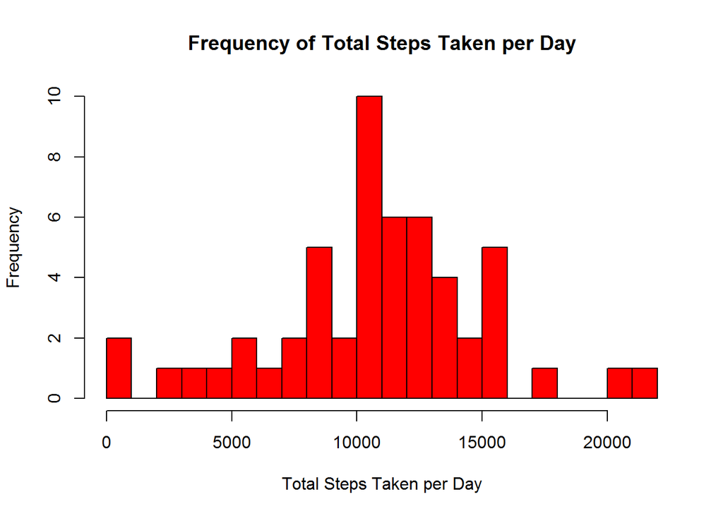

```r
hist(TStepsPerDay$TotalSteps,breaks=20,main="Frequency of Total Steps Taken per Day",
col='red',xlab='Total Steps Taken per Day')
```

**3.Calculate and report the mean and median of the total number of steps taken per day**

```r
mean(TStepsPerDay$TotalSteps)
```

```
## [1] 10766.19
```

```r
median(TStepsPerDay$TotalSteps)
```

```
## [1] 10765
```

Mean and median of total number of steps taken per day are 10766 and 10765.

## What is the average daily activity pattern?

**1.Make a time series plot (i.e. type = “l”) of the 5-minute interval (x-axis) and the average number of steps taken, averaged across all days (y-axis)**

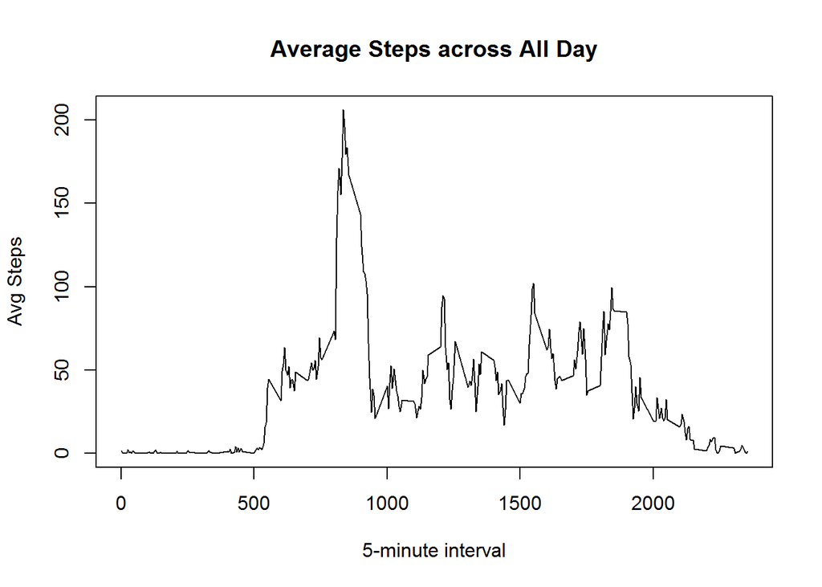

```r
AvgStepsInterval<-aggregate(dfgood$steps, list(dfgood$interval), mean) #mean
colnames(AvgStepsInterval) <- c("interval", "AvgSteps") #change column names
plot(AvgStepsInterval$interval,AvgStepsInterval$AvgSteps,type='l',
     main='Average Steps across All Day',xlab='5-minute interval',ylab='Avg Steps')
```

From above plot, we can see majority of the steps are taken from 500 to 2000 5-minute interval with a peak around 800 5-minute interval.

**2.Which 5-minute interval, on average across all the days in the dataset, contains the maximum number of steps?**

```r
subset(AvgStepsInterval, AvgStepsInterval$AvgSteps==max(AvgStepsInterval$AvgSteps))
```

```
##     interval AvgSteps
## 104      835 206.1698
```

The maximum number of steps is 206 at 5-minute interval of 835.

## Imputing missing values

Note that there are a number of days/intervals where there are missing values (coded as NA). The presence of missing days may introduce bias into some calculations or summaries of the data.

**1.Calculate and report the total number of missing values in the dataset (i.e. the total number of rows with NAs)**

```r
str(dfbad)
```

```
## 'data.frame':    2304 obs. of  6 variables:
##  $ steps    : int  NA NA NA NA NA NA NA NA NA NA ...
##  $ date     : Factor w/ 61 levels "2012-10-01","2012-10-02",..: 1 1 1 1 1 1 1 1 1 1 ...
##  $ interval : int  0 5 10 15 20 25 30 35 40 45 ...
##  $ dateval  : Date, format: "2012-10-01" "2012-10-01" ...
##  $ day      : chr  "Monday" "Monday" "Monday" "Monday" ...
##  $ IsWeekday: chr  "weekday" "weekday" "weekday" "weekday" ...
```

```r
table(dfbad$dateval)
```

```
##
## 2012-10-01 2012-10-08 2012-11-01 2012-11-04 2012-11-09 2012-11-10
##        288        288        288        288        288        288
## 2012-11-14 2012-11-30
##        288        288
```

There are 2304 NAs in steps which are related to 8 individual days.

**2.Devise a strategy for filling in all of the missing values in the dataset. The strategy does not need to be sophisticated. For example, you could use the mean/median for that day, or the mean for that 5-minute interval, etc.**

```r
refdf<-aggregate(dfgood$steps, list(dfgood$day,dfgood$interval), mean) #mean
colnames(refdf) <- c("day","interval" ,"AvgSteps") #rename
head(refdf)
```

```
##        day interval AvgSteps
## 1   Friday        0 0.000000
## 2   Monday        0 1.428571
## 3 Saturday        0 0.000000
## 4   Sunday        0 0.000000
## 5 Thursday        0 5.875000
## 6  Tuesday        0 0.000000
```

**3.Create a new dataset that is equal to the original dataset but with the missing data filled in.**

```r
library(sqldf) #Install sqldf package
library(tcltk) #Install tcltk package
simbaddf<-sqldf("select b.AvgSteps as steps,
                        a.date,
                        a.interval,
                        a.dateval,
                        a.day,
                        a.IsWeekday
                   from dfbad as a join refdf as b
                     on a.interval=b.interval and a.day=b.day")
                #replace in dfbad
head(simbaddf)
```

```
##   steps       date interval    dateval    day IsWeekday
## 1     1 2012-10-01        0 2012-10-01 Monday   weekday
## 2     0 2012-10-01        5 2012-10-01 Monday   weekday
## 3     0 2012-10-01       10 2012-10-01 Monday   weekday
## 4     0 2012-10-01       15 2012-10-01 Monday   weekday
## 5     0 2012-10-01       20 2012-10-01 Monday   weekday
## 6     5 2012-10-01       25 2012-10-01 Monday   weekday
```

```r
simdf<-sqldf("select * from dfgood union select * from simbaddf")
             # combine both good dataframe and simulated bad dataframe
head(simdf)
```

```
##   steps       date interval    dateval    day IsWeekday
## 1     0 2012-10-01        5 2012-10-01 Monday   weekday
## 2     0 2012-10-01       10 2012-10-01 Monday   weekday
## 3     0 2012-10-01       15 2012-10-01 Monday   weekday
## 4     0 2012-10-01       20 2012-10-01 Monday   weekday
## 5     0 2012-10-01       30 2012-10-01 Monday   weekday
## 6     0 2012-10-01       35 2012-10-01 Monday   weekday
```

**4.Make a histogram of the total number of steps taken each day and Calculate and report the mean and median total number of steps taken per day. Do these values differ from the estimates from the first part of the assignment? What is the impact of imputing missing data on the estimates of the total daily number of steps?**

```r
simTStepsPerDay<-aggregate(simdf$steps, list(simdf$date), sum) #sum total steps per day
colnames(simTStepsPerDay) <- c("date", "TotalSteps") #change column names
head(simTStepsPerDay)
```

```
##         date TotalSteps
## 1 2012-10-01       9888
## 2 2012-10-02        126
## 3 2012-10-03      11352
## 4 2012-10-04      12116
## 5 2012-10-05      13294
## 6 2012-10-06      15420
```

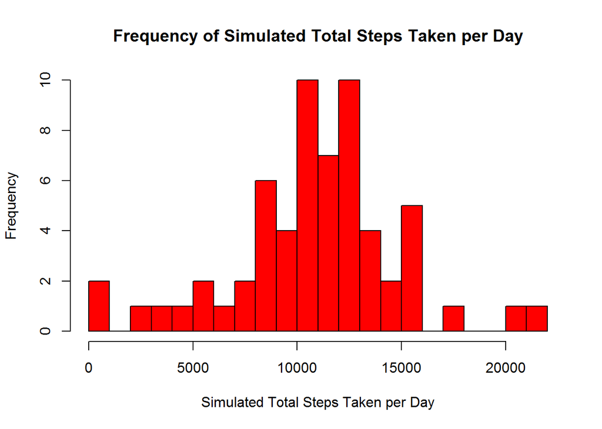

```r
hist(simTStepsPerDay$TotalSteps,breaks=20,
     main="Frequency of Simulated Total Steps Taken per Day",
     col='red',xlab='Simulated Total Steps Taken per Day')
```

```r
mean(simTStepsPerDay$TotalSteps)
```

```
## [1] 10809.79
```

```r
median(simTStepsPerDay$TotalSteps)
```

```
## [1] 11015
```

## Are there differences in activity patterns between weekdays and weekends?

**Make a panel plot containing a time series plot (i.e. type = “l”) of the 5-minute interval (x-axis) and the average number of steps taken, averaged across all weekday days or weekend days (y-axis). See the README file in the GitHub repository to see an example of what this plot should look like using simulated data.**

```r
simAvgStepsPerInt<-aggregate(simdf$steps, list(simdf$IsWeekday,simdf$interval), mean) #avg steps per interval
colnames(simAvgStepsPerInt) <- c("IsWeekday", "interval", "AvgSteps") #change column names
head(simAvgStepsPerInt)
```

```
##   IsWeekday interval  AvgSteps
## 1   weekday        0 2.2666667
## 2   weekend        0 0.0000000
## 3   weekday        5 0.4444444
## 4   weekend        5 0.0000000
## 5   weekday       10 0.1555556
## 6   weekend       10 0.0000000
```

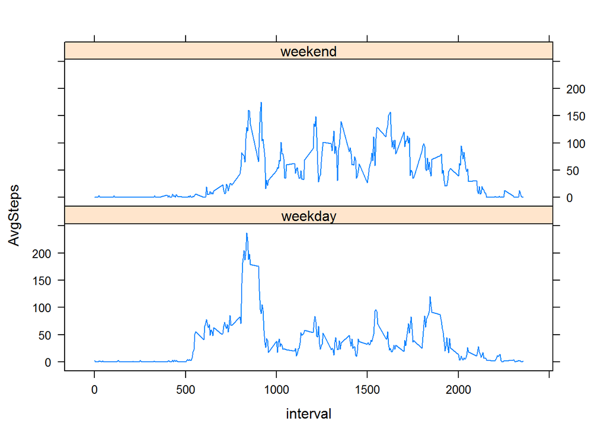

```r
library(lattice)
xyplot(AvgSteps~interval|IsWeekday,layout=c(1,2),type="l",
       data=simAvgStepsPerInt,
       title="Average of Steps Taken per 5-minute Interval Group by Weekday and Weekend")
```

It is interesting to see on weekends, the majority of steps are shifted to a later 5-minute interval and less skewed. On weekdays, more steps are taken from 800 to 1000 5-minute interval. Also on weekdays, after the rush hour, less steps are taken than weekends. All these outcomes meet our life style – From Monday to Friday, we have to rush to work and focus on our duties with less walk. On weekends, we get up late and have a leisure life style.